# Amir Voloshin

## Model Testing on Video

```
count-------------- 0
Number of frames processed so far: 1
Number of frames processed so far: 201
Number of frames processed so far: 401
Number of frames processed so far: 601
Number of frames processed so far: 801
Number of frames processed so far: 1001
Number of frames processed so far: 1201
Number of frames processed so far: 1401
Number of frames processed so far: 1601
Reached the end of the video!
Took 83.57073497772217
Releasing out
```

# Extra (Training Model with more epochs)

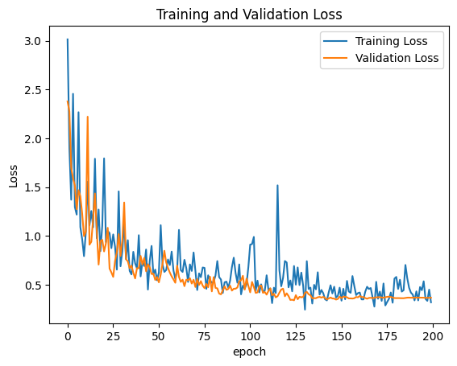

## Extra Model Validation Report

Once again there is a noticeable difference in the Average Precision between the original and quantized model, surprisingly the difference is in favor of the quantized model. This can be seen with some of the other metrics as well.

COCO metrics **Original Model Longer Training**:  
AP: 0.5614750981330872  
AP50: 0.9760345220565796  
AP75: 0.5791326761245728  
APs: -1.0  
APm: 0.6000000238418579  
APl: 0.5645578503608704  
ARmax1: 0.5038461685180664  
ARmax10: 0.6269230842590332  
ARmax100: 0.6384615302085876  
ARs: -1.0  
ARm: 0.6000000238418579  
ARl: 0.6399999856948853  
AP_/boards: 0.5614750981330872  
COCO metrics **Quantized Model Longer Training**:  
AP: 0.6168215274810791  
AP50: 0.9763253927230835  
AP75: 0.7413140535354614  
APs: -1.0  
APm: 0.699999988079071  
APl: 0.618201494216919  
ARmax1: 0.5461538434028625  
ARmax10: 0.6846153736114502  
ARmax100: 0.6846153736114502  
ARs: -1.0  
ARm: 0.699999988079071  
ARl: 0.6840000152587891  
AP_/boards: 0.6168215274810791\

## Object Detection in Video with Extra Model

```
count-------------- 0
Number of frames processed so far: 1
Number of frames processed so far: 201
Number of frames processed so far: 401
Number of frames processed so far: 601
Number of frames processed so far: 801
Number of frames processed so far: 1001
Number of frames processed so far: 1201
Number of frames processed so far: 1401
Number of frames processed so far: 1601
Reached the end of the video!
Took 84.27179431915283 seconds
Releasing out
```